# Usertype Patronage Behaviour (Bay-Area Bikeshare)

## James Funware West

## Investigation Overview

In this investigation, we will place our focus on different usertypes and their patronage behaviour of our bikeshare services. We will focus on their numbers,how they differ in duration of their trips and time of the day they take these trips.

## Dataset Overview

This data set includes information about individual rides made in a bike-sharing system covering the greater San Francisco Bay area. The dataset is for February 2019. The data can be gotten from the sources below :

- Website: http://www.bayareabikeshare.com/
- Systems Data Page: http://www.bayareabikeshare.com/open-data
- Data being shared: Trip, Station, Membership, Weather, Bike and Dock Availability

## General Characteristics Of Users

90.8% of the users are subscribers, while 9.2% are customers. Most of our users are subscribers and only a small number are customers.

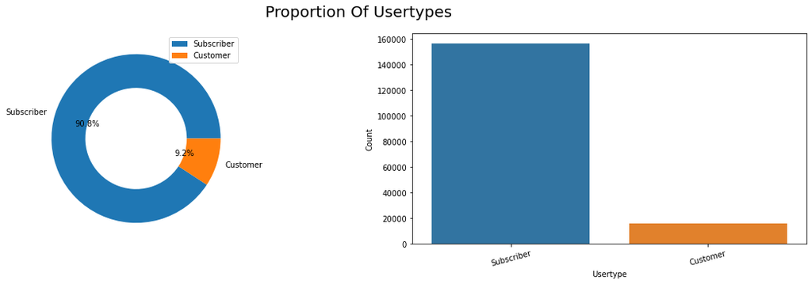

## Age Distribution

The distribution is right skewed, most of our customers are between the age 25 and 40. This might imply that most of our customers use our bikeshare services to get to work. Let's check out the number of trips for each hour of the day.

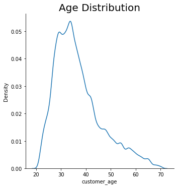

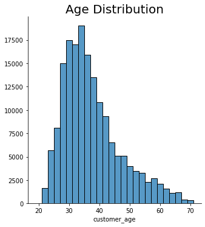

## Top 10 Busiest Stations

`Market St at 10th St.` and `San Francisco Caltrain Station 2 (Townsend St at 4th St)` ranks as the busiest stations. As we would expect, among the top 10 stations most of the users are subscribers but `San Francisco Ferry Building (Harry Bridges Plaza)` is quite popular among customers.

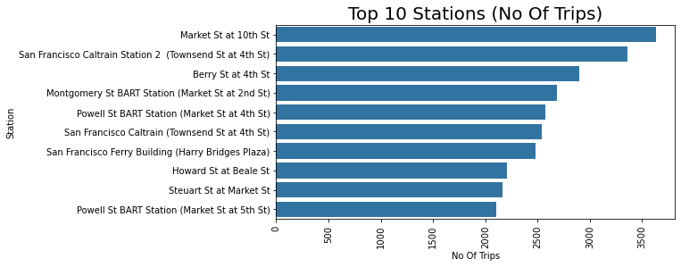

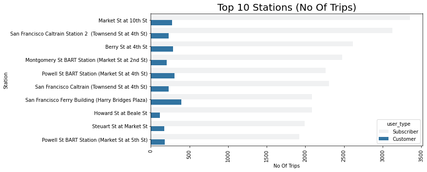

## Let's See How The Behaviour Of Usertypes Change..

Usertype behaviour changes with the time of day, day of the week. Let's see how these factors affect usertype behaviour.

## Trip Duration For Usertypes

Customers record longer trips, while subscribers record shorter trips, further analysis will show the time of the day and the day of the week these rides were taken.

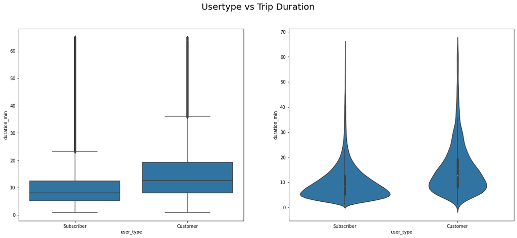

## Number Of Trips Booked Each Hour Of The Day

There is a spike during rush hour and this is significantly caused by subscribers, this inturn confirms that our subscribers use bikeshare for transit to work. Customer's activity remains relatively constant during the day and this goes to show they are for leisure rides.

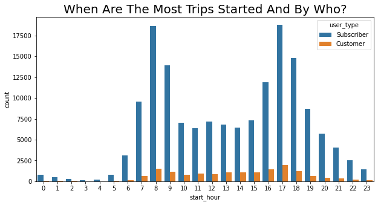

## Duration Of Trips Booked Each Day Of The Week

[figure not shown]